# Homework 1

### Exercise 1.9

Discrete random variable $Y$ has a Poisson distribution with parameter $\lambda$ if its p.d.f. is $f(y)=\lambda^y e^{-\lambda}/y!$, for $y = 0, 1, \dots$.

1. Find the moment generating function for $Y$ (hint: the power series repre-sentation of the exponential function is useful).

*For* $t\in\mathbb{R}$
$$M_Y(t)=E(e^{tY})=\sum_{y=0}^{\infty}e^{ty}\frac{\lambda^ye^{-\lambda}}{y!}=e^{-\lambda}\sum_{y=0}^{\infty}\frac{(\lambda e^t)^y}{y!}=e^{\lambda(e^t-1)}$$

2. If $Y_1\sim Poi(\lambda_1)$ and independently $Y_2\sim Poi(\lambda_2)$, deduce the distribution of $Y_1+Y_2$, by employing a general property of m.g.f.s.

*The condition*
$$M_{Y_1+Y_2}(t)=M_{Y_1}(t)M_{Y_2}(t)=e^{\lambda_1(e^t-1)}e^{\lambda_2(e^t-1)}=e^{(\lambda_1+\lambda_2)(e^t-1)}$$
*holds for every $t\in\mathbb{R}$, so* $Y_1+Y_2\sim Poi(\lambda_1+\lambda_2).$

3. Making use of the previous result and the central limit theorem, deduce the normal approximation to the Poisson distribution.

4. Confirm the previous result graphically, using R functions `dpois` , `dnorm` , `plot` or `barplot` and `lines`. Confirm that the approximation improves with increasing $λ$ .

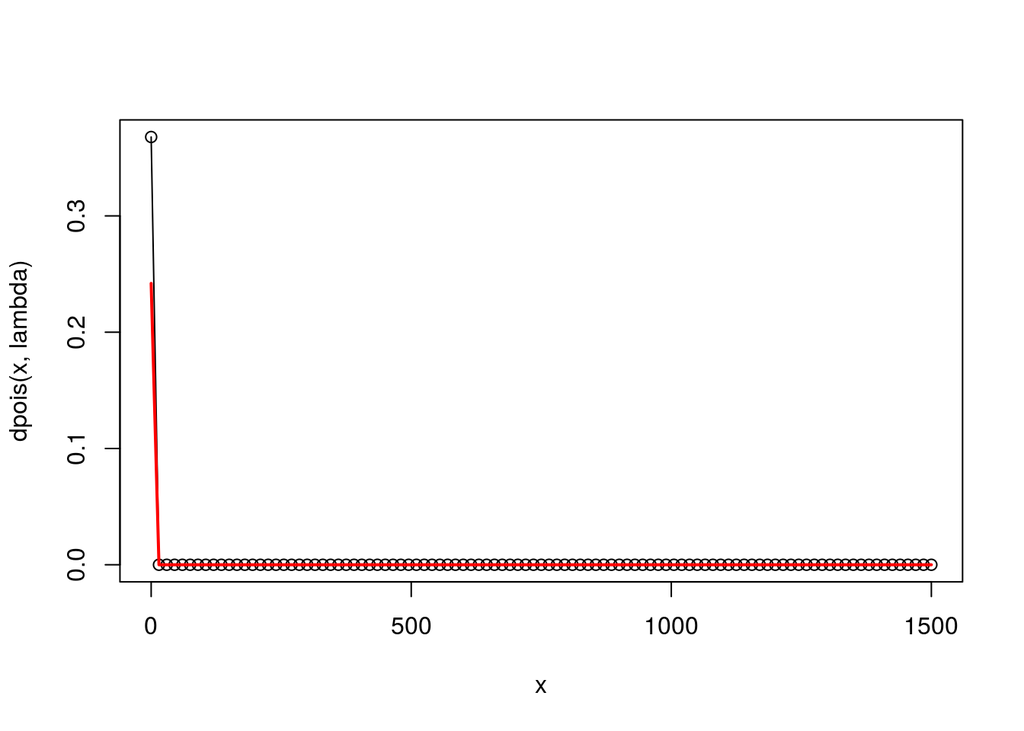

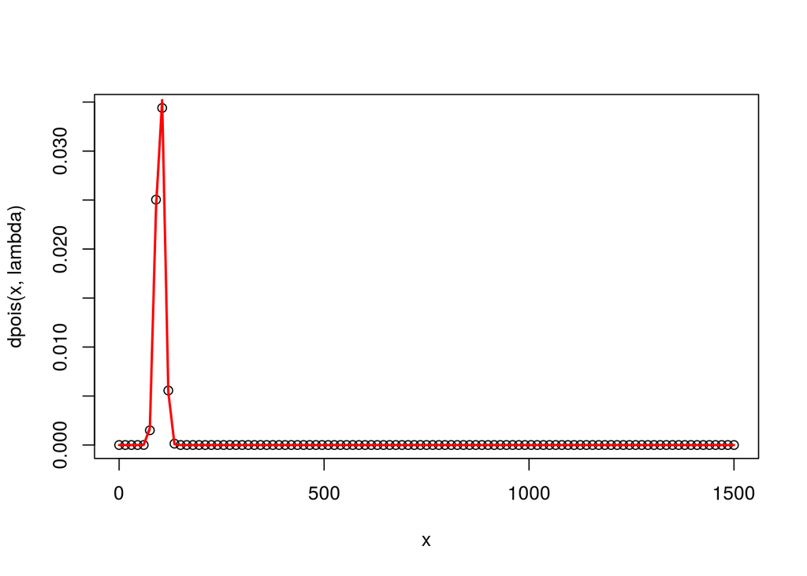

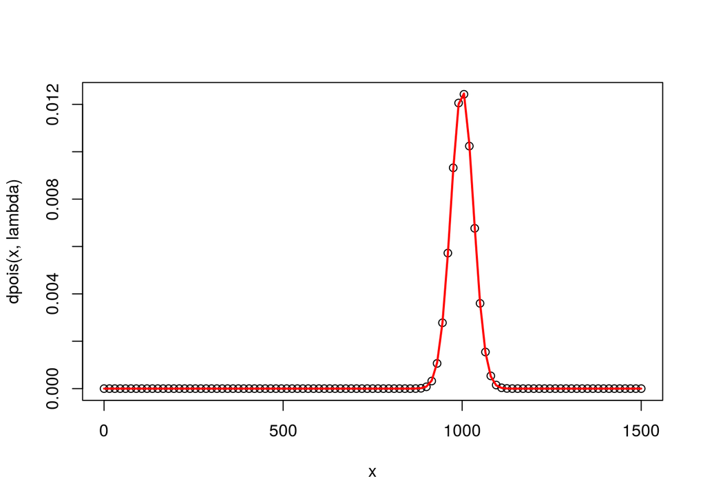

```r
for (lambda in c(1, 100, 1000)){
  curve(dpois(x, lambda), xlim=c(0,1500), type = "o")
  curve(dnorm(x, lambda, sqrt(lambda)), col="red", lwd=2, add=TRUE)
}
```

## LAB

### Exercise 1

- Write a function $\mathsf{binomial(x,n,p)}$ for the binomial distribution, depending on parameters $\mathsf{x,n,p}$, and test it with some prespecified values. Use the function $\mathsf{choose()}$ for the binomial coefficient.

```r
binomial <- function(x,n,p){
 y=choose(n,x)*p^{x}*(1-p)^{n-x}
return(y)
}
```

- Plot two binomials with $n=20$, and $p=0.3, 0.6$ respectively.

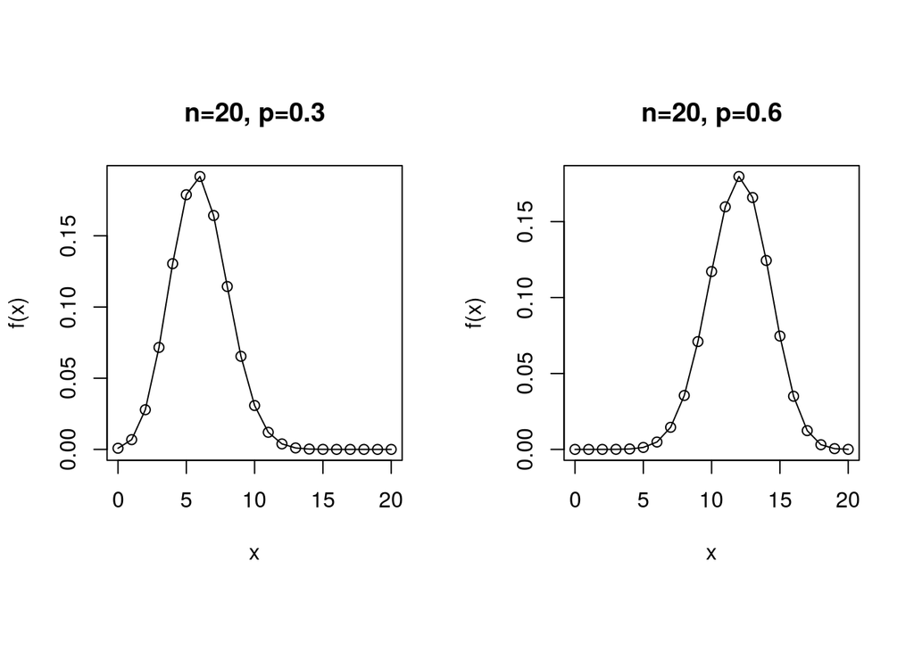

```r
#graphical setting for margins and type of points
par(mfrow=c(1,2), pty="s")
#plot the binomial distributions with different input
plot(0:20, binomial(0:20, 20, 0.3), type = "o", xlab = "x", ylab = "f(x)", main="n=20, p=0.3")
plot(0:20, binomial(0:20, 20, 0.6),  type = "o", xlab = "x", ylab = "f(x)", main="n=20, p=0.6")
```

### Exercise 2

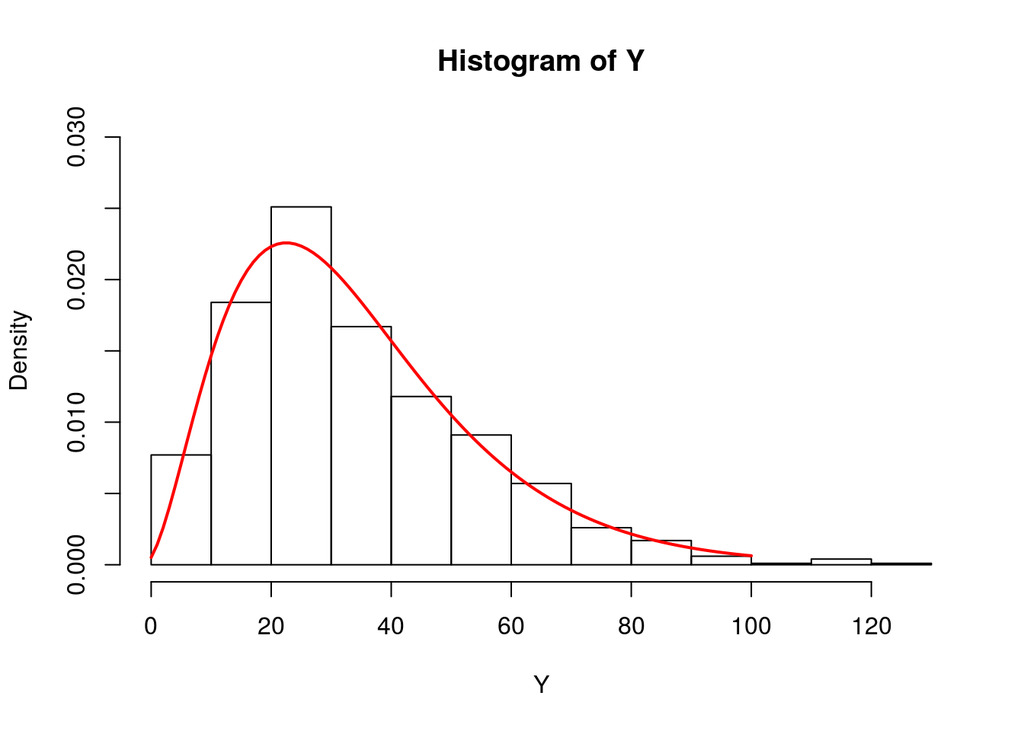

```r
par(mfrow=c(1,1))
n <- 1000 # sample size
p <- 0.08 # success probability
k <- 3    # predef. number of successes

X <- matrix(NA, n, 3)
for (i in 1:n){
  X[i,] <- rgeom(3, p) # store in the i-th row
}
Y <- apply(X, 1, sum) # sum over rows

hist(Y, ylim=c(0,0.03) ,probability = TRUE)
curve(dnbinom(x, 3, p), col="red", lwd=2, add=TRUE, xlim=c(0,100))
```

### Exercise 3

- Show in $\mathsf{R}$, also graphically, that $\mbox{Gamma}(n/2, 1/2)$ coincides with a $\chi^{2}_{n}$.

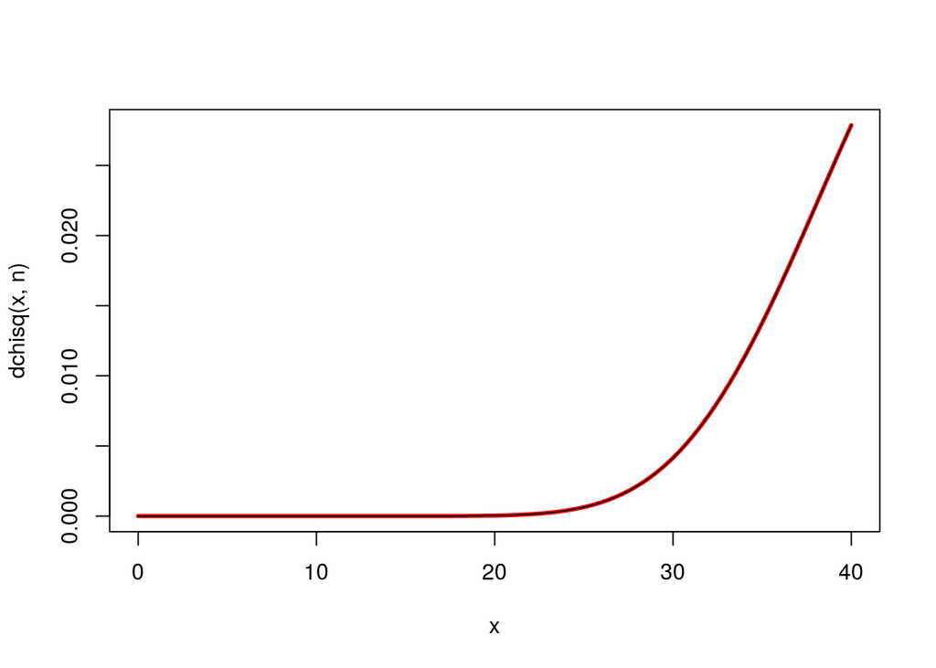

```r
n<-50          #sample size
curve(dchisq(x, n), col="red", lwd=3, xlim=c(0,40))
curve(dgamma(x, n/2, 1/2), col="black", lwd=1, add=TRUE,  xlim=c(0,40))
```

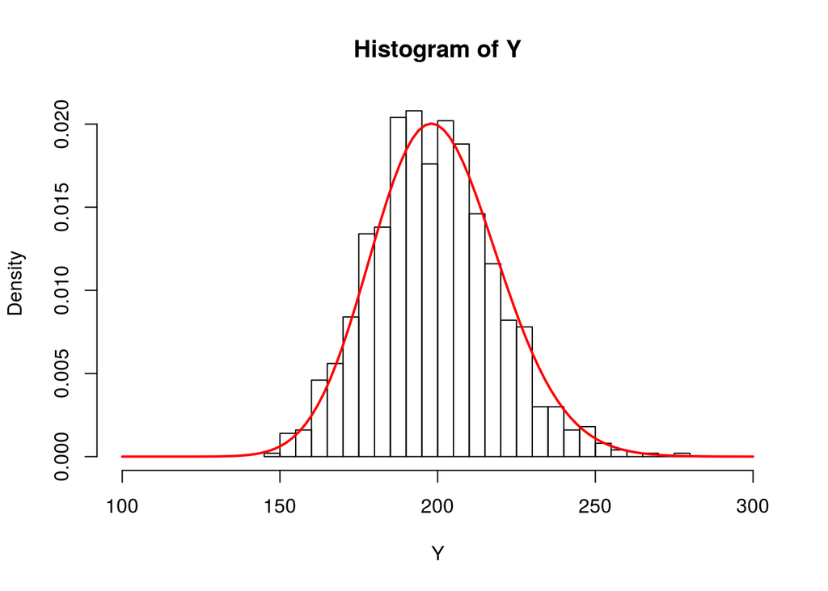

```r
n<-1000          #sample size
k<-2
sample_rep<-100 # number of distributions
X<-matrix(NA, n, sample_rep)
for (h in 1:n){
  X[h,]<-rchisq(sample_rep, k)
}
Y<-apply(X,1,sum)
hist(Y, breaks=40, probability=TRUE, xlim=c(100,300))

curve(dgamma(x, sample_rep*k/2, 1/2), col="red", lwd=2, add=TRUE)
```

- Find the 5% and the 95% quantiles of a $\mbox{Gamma}(3,3)$.

```r
q1<-qgamma(0.05,3,3)
q2<-qgamma(0.95,3,3)
q1
```

```
## [1] 0.2725638
```

```r
q2
```

```
## [1] 2.098598
```

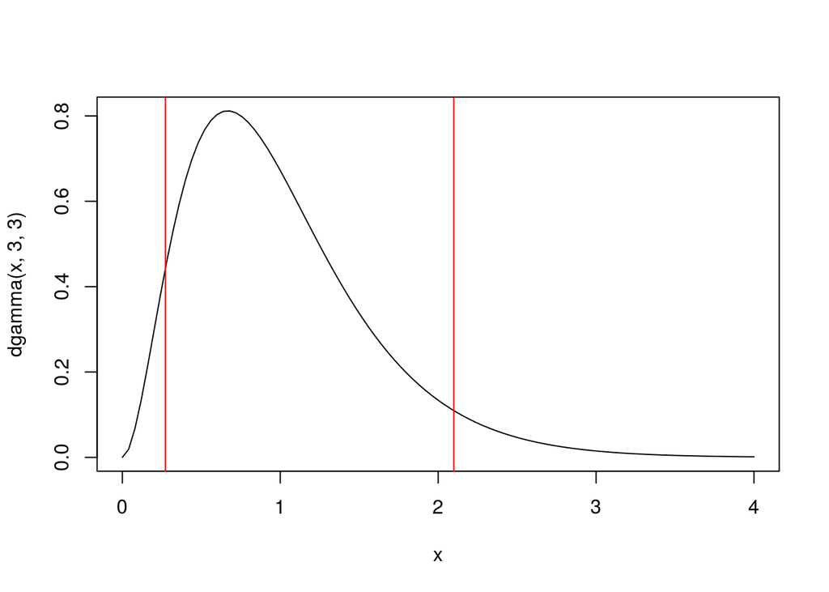

```r
curve(dgamma(x,3,3), from=0, to=4)
abline(v=q1, col = "red")
abline(v=q2, col = "red")
```

### Exercise 4

- Generate $n=1000$ values from a $\mbox{Beta}(5,2)$ and compute the sample mean and the sample variance.

```r
z <- rbeta(1000, 5, 2)
mean(z)
```

```
## [1] 0.7114163
```

```r
var(z)
```

```
## [1] 0.02524088
```

### Exercise 5

- Analogously, show with a simple $\mathsf{R}$ function that a negative binomial distribution may be seen as a mixture between a Poisson and a Gamma. In symbols: $X|Y \sim \mathcal{P}(Y)$, $Y \sim \mbox{Gamma}(\alpha, \beta)$, then $X \sim \ldots$.

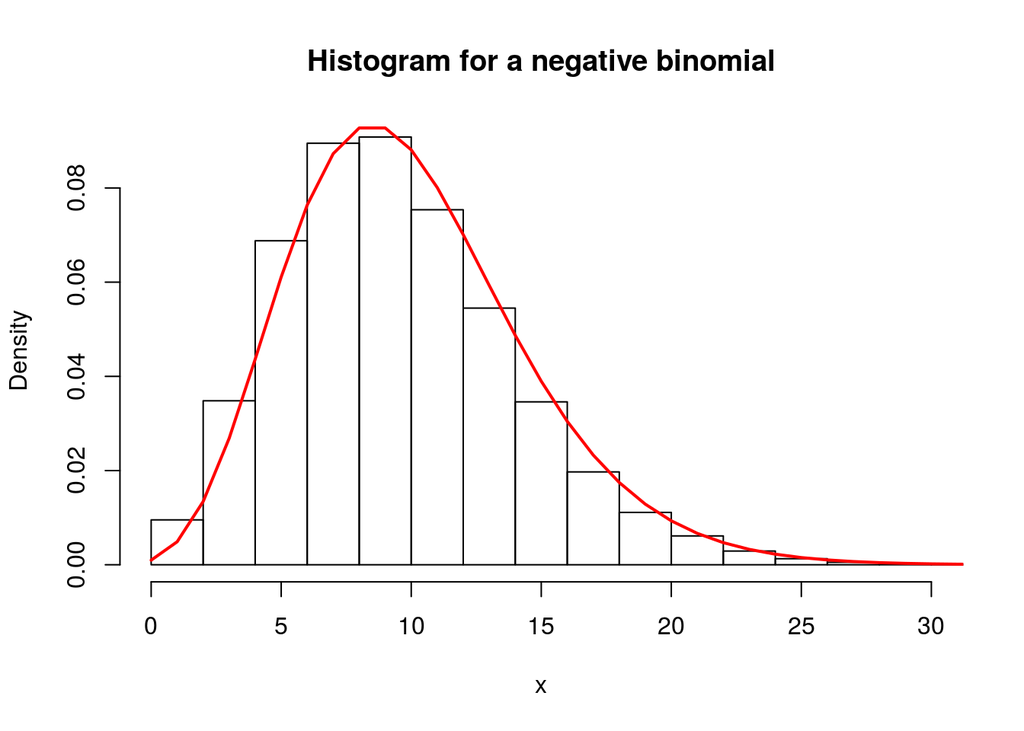

```r
mixture <- function(r, p, n){

  Y=rgamma(n, r, (1-p)/p)
  X=rpois(n, Y)
  return(X)

}

p<-0.5
r<-10
n<-100000
hist(mixture(r, p, n), probability=TRUE, breaks=20, main="Histogram for a negative binomial", xlab="x", xlim = c(0,30))
curve(dnbinom(x, r, p), xlim=c(0,100), add=TRUE, col="red", lwd=2)
```

### Exercise 6

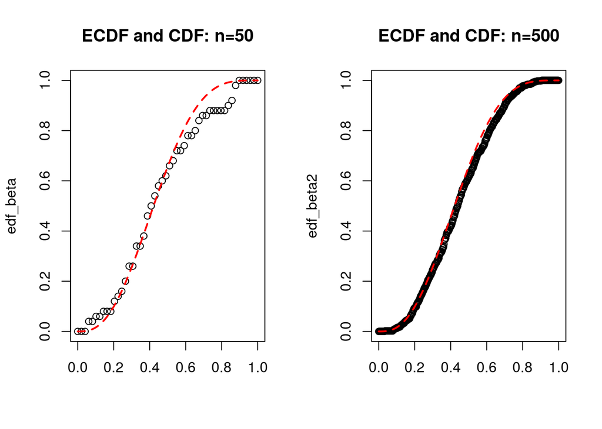

```r
my_ecdf <- function(y){
  out <- c()
  x <- seq(0,1,1/length(y))
  for (i in 0:length(y)) {
    out[i] <- length(which(y<=x[i]))/length(y)
  }
  return(out)
}

set.seed(2)

n<-50
par(mfrow=c(1,2))
y<-rbeta(n, 3, 4)
edf_beta <- my_ecdf(y)
tt<-seq(from=0, to=1, by=0.01)
plot(x=seq(from=0, to=1, by=1/(n-1)), y=edf_beta, main="ECDF and CDF: n=50", xlab=' ')
lines(tt, pbeta(tt,3,4), col=2, lty=2, lwd=2)

n2<-500
y2<-rbeta(n2, 3,4)
edf_beta2<-my_ecdf(y2)
tt<-seq(from=0, to=1, by=0.01)
plot(x=seq(from=0, to=1, by=1/(n2-1)), edf_beta2, main="ECDF and CDF: n=500", xlab=' ')
lines(tt, pbeta(tt,3,4), col=2, lty=2, lwd=2)
```

### Exercise 7

Compare in $\mathsf{R}$ the assumption of normality for these samples:

- $y_1, \ldots, y_{100} \sim t_{\nu},$ with $\nu=5,20, 100$. What happens when the number of degrees of freedom $\nu$ increases?

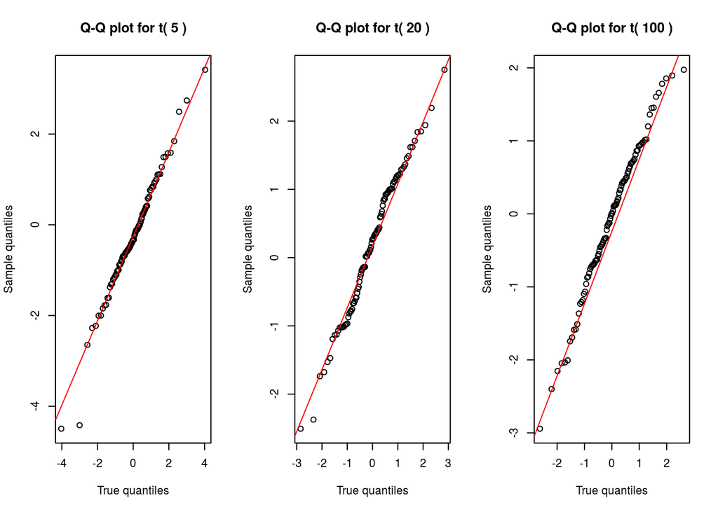

```r
par(mfrow=c(1,3))
n<-100

for (v in c(5,20,100)) {
  y<-rt(n, v)
  qqplot(qt(ppoints(n),v), y,
    xlab="True quantiles", ylab="Sample quantiles",
    main = paste("Q-Q plot for t(",v,")"))
  qqline(y, distribution = function(p) qt(p, v),
       prob = c(0.1, 0.9), col = 2)
}
```

```r
par(mfrow=c(1,1))
```

*When the number of degrees of freedom increases tails become lighter and the normal approximation becomes more plausible.*

- $y_1, \ldots, y_{100} \sim \mbox{Cauchy}(0,1)$. Do you note something weird for the extremes quantiles? Plot together a $\mbox{Cauchy}(0,1)$ and a $\mbox{Normal}(0,1)$ and give an intuition of this.

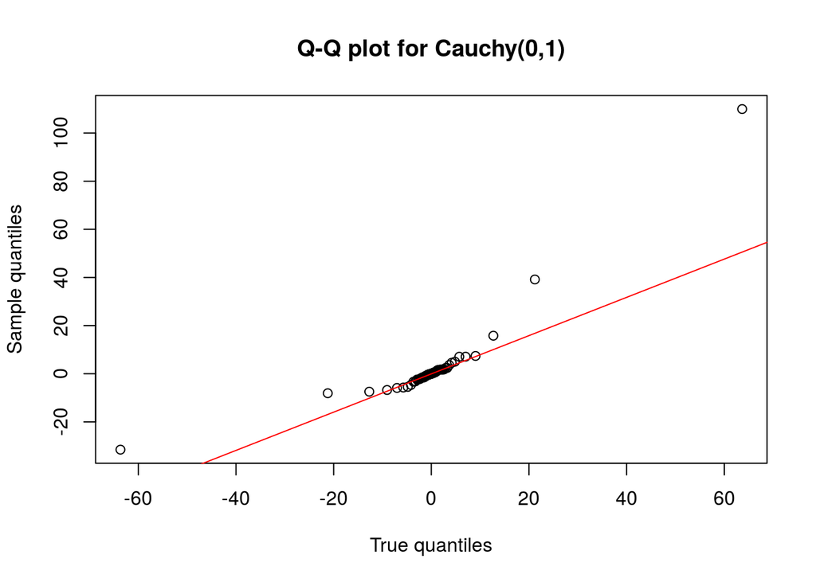

```r
n<-100
y<-rcauchy(n, 0,1)
qqplot(qcauchy(ppoints(n),0,1), y,
  xlab="True quantiles", ylab="Sample quantiles",
  main = "Q-Q plot for Cauchy(0,1)")
qqline(y, distribution = function(p) qcauchy(p, 0,1),
       prob = c(0.1, 0.9), col = 2)
```

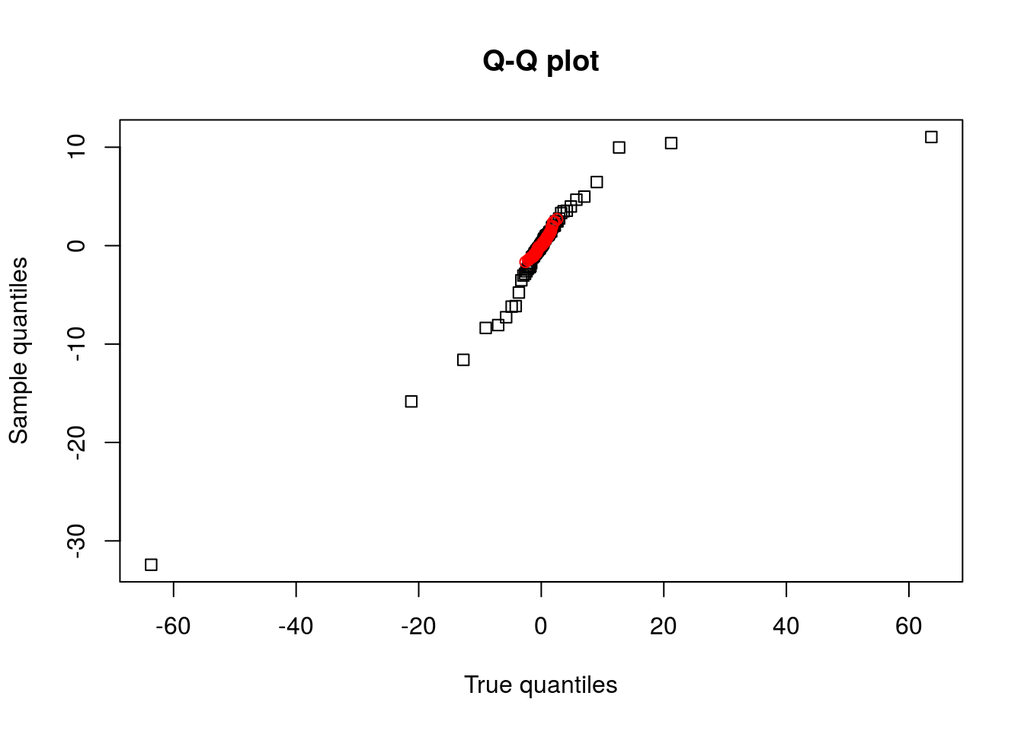

```r
n <- 100
z1 <- rnorm(n, 0, 1)
z2 <- rcauchy(n, 0, 1)
##########
q1 <- qqplot(qcauchy(ppoints(n),0,1), rcauchy(n, 0,1), plot.it = FALSE)
q2 <- qqnorm(z1, plot.it = FALSE)
plot(range(q1$x, q2$x), range(q1$y, q2$y), type = "n", xlab="True quantiles", ylab="Sample quantiles", main = "Q-Q plot")
points(q1, col = "black", pch = 0)
points(q2, col = "red", pch = 1)
```

*Extreme quantiles in Cauchy distribution enhance the fact that it’s a fat-tailed distribution.*

### Exercise 8

Write a general $\mathsf{R}$ function for checking the validity of the central limit theorem. *Hint* The function will consist of two parameters: clt_function <- function($\mathsf{n}$, $\mathsf{distr}$), where the first one is the sampe size and the second one is the kind of distribution from which you generate. Use plots for visualizing the results.

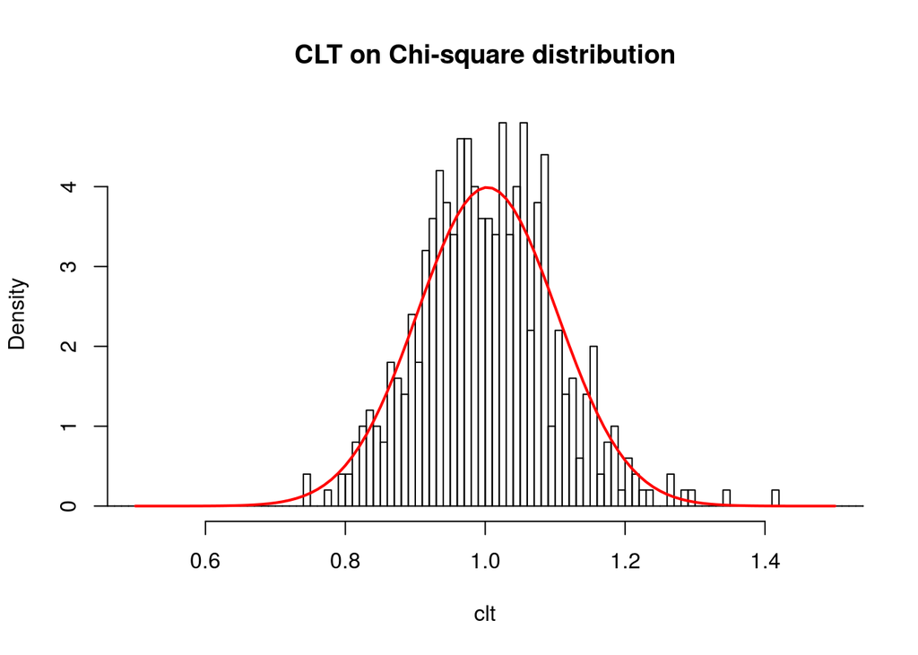

```r
set.seed(123)

clt_function <- function(n,distr){
   size  = length ( distr ) / n
   sample_means = rep(0,size+1)
   for (i in 1:size) {
    sample_means[i] = mean ( distr[(i*n + 1):(i*n + n)] )
   }
  return(sample_means)
}

sample_size=100000
n=200
distr = rchisq ( sample_size , df = 1 ,ncp=0)
clt <- clt_function(n, distr)
hist(clt, breaks = c(seq(from = 0, to = 10, by = 0.01)),xlim = c(0.5,1.5),probability = TRUE, main="CLT on Chi-square distribution")
curve(dnorm(x,mean=mean(distr),sqrt(var(distr)/n)),add=TRUE,lwd=2,col="red")
```

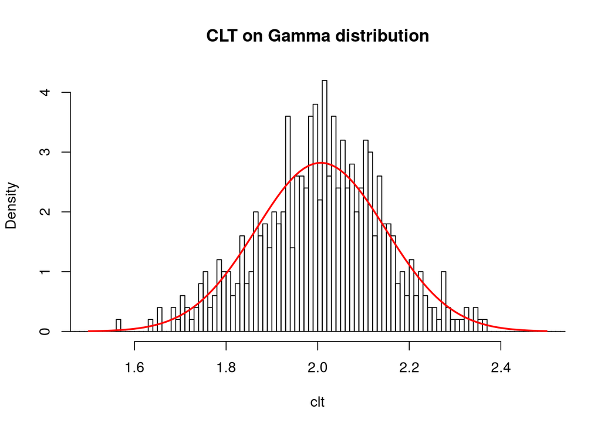

```r
sample_size=100000
n=200
distr = rgamma ( sample_size , 1, 0.5)
clt <- clt_function(n, distr)
hist(clt, breaks = c(seq(from = 0, to = 10, by = 0.01)),xlim = c(1.5,2.5),probability = TRUE, main="CLT on Gamma distribution")
curve(dnorm(x,mean=mean(distr),sqrt(var(distr)/n)),add=TRUE,lwd=2,col="red")
```

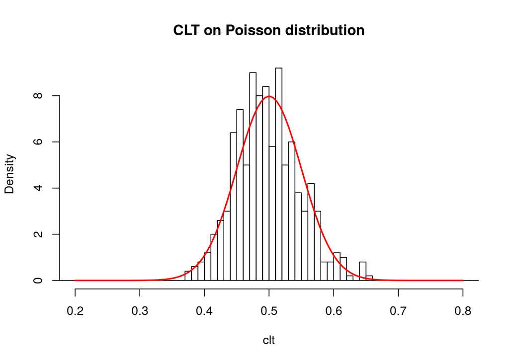

```r
sample_size=100000
n=200
distr = rpois (sample_size , 0.5)
clt <- clt_function(n, distr)
hist(clt, breaks = c(seq(from = 0, to = 10, by = 0.01)),xlim = c(0.2,0.8),probability = TRUE,main="CLT on Poisson distribution")
curve(dnorm(x,mean=mean(distr),sqrt(var(distr)/n)),add=TRUE,lwd=2,col="red")
```